# Social Network - Assignment #1

Author

Aurora Sterpellone - Gür Piren

Published

April 22, 2025

# 1 Introduction

Through this file, we will reveal the number and nature of the partnerships between heroes, villains, and neutral characters across the Marvel Universe. While doing so, we will try to answer a number of questions that were raised as part of the first homework assignment for the Social Network Analysis.

## 1.1 Libraries

```r
library(igraph)
library(stringr)
library(dplyr)
library(ggraph) # ultimately, might not use it. check at the end
library(tidygraph) # ultimately, might not use it. check at the end
library(ggrepel)
library(extrafont)
```

## 1.2 1. Choose a network dataset

Marvel character partnerships, 2018. The dataset can be accessed through this [link](https://networks.skewed.de/net/marvel_partnerships)

## 1.3 2. Indicate the number of nodes should be larger than 300 but smaller than 10000.**

The number of nodes is 350.

```r
load("marvel_network.rda")

# for the number of nodes
num_nodes <- vcount(marvel_network)

cat("Number of nodes:", num_nodes)
```

```
Number of nodes: 350
```

## 1.4 3. Import that data and create a graph using R.

Reading the data

```r
marvel_nodes <- read.csv("data/nodes.csv", stringsAsFactors = FALSE, quote = "\"", fill = TRUE)

marvel_links <- read.csv("data/edges.csv", stringsAsFactors = FALSE)
```

### 1.4.1 Data description

Initially, we have two datasets separately for nodes and links. Later on, they will be merged.

1. The dataset for the nodes includes the following variables:

**id:** The index number of the character in the network.

**character_name:** The name of the character, which could be a hero, villain, or neutral character.

**group:** Indicates the category of the character (e.g., hero, villain, or neutral).

**size:** Represents the number of partnerships the character has within the network.

**x:** The X-coordinate that positions the character in the network layout.

**y:** The Y-coordinate that positions the character in the network layout.

2. The dataset for the links, on the other hand, incorporates the following variables:

**source:** This column represents the starting character in a partnership (the character initiating or belonging to the partnership).

**target:** This column indicates the partner in the relationship with the source character.

### 1.4.2 Data cleaning

Let’s read both datasets, treating text as characters (not factors), and ensuring quotes and missing data are handled properly.

```r
# to get proper x and y coordinates

marvel_nodes$pos_x <- as.numeric(str_extract(marvel_nodes$X_pos, "-?\\d+\\.\\d+"))
marvel_nodes$pos_y <- as.numeric(str_extract_all(marvel_nodes$X_pos, "-?\\d+\\.\\d+") %>% sapply(`[`, 2))

# we don't need the X_pos anymore
marvel_nodes$X_pos <- NULL
```

### 1.4.3 Renaming columns

To improve readability, we will rename certain columns in both datasets. After that, we will remove any alternative names or descriptions that appear in parentheses following a character’s name.

```r
marvel_nodes <- marvel_nodes |>
  rename(id = X..index,
         character_name = id,
         x = pos_x,
         y = pos_y)

marvel_links <- marvel_links |>
  rename(source = X..source,
         target = target)

# let's get rid of anything that is in parentheses in the character_name columns
marvel_nodes$character_name <- gsub(" \\(.*?\\)", "", marvel_nodes$character_name)
```

### 1.4.4 Plot

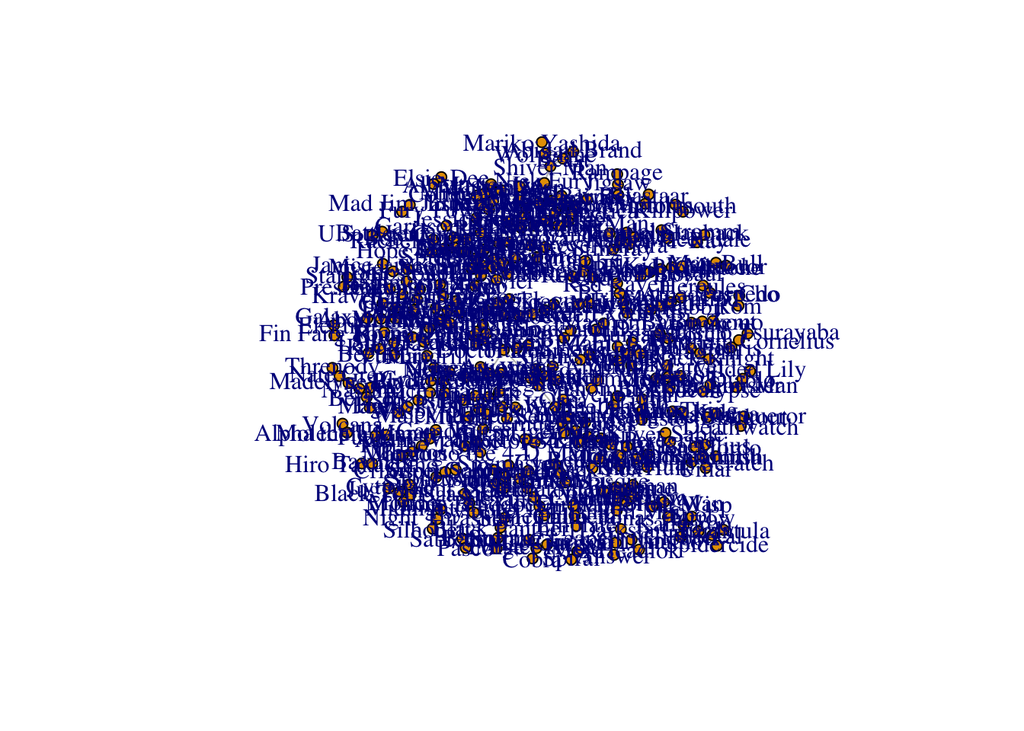

```r
marvel_network <- graph_from_data_frame(d = marvel_links, vertices = marvel_nodes, directed = FALSE)

plot(marvel_network, vertex.label = V(marvel_network)$character_name, vertex.size = 5, edge.color = "gray")
```

```r
save(marvel_network, file = "marvel_network.rda")
```

Let’s work on a cleaner plot, ideally we wanted to plot it with those characters that has the biggest sizes (number of partnerships) only, but we were not able to position the node labels clearly.

For the font of use

```r
font_import(pattern = "Marvel")
```

```
Importing fonts may take a few minutes, depending on the number of fonts and the speed of the system.
Continue? [y/n]
```

```r
loadfonts()

# setting font globally
par(family = "Marvel")
```

For the colours, we created a unique palette using the colours for the main Marvel superheroes:

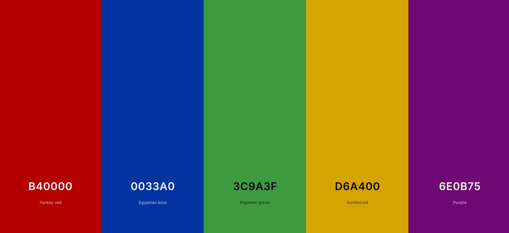

Marvel Color Palette

1. Iron Man Red – #B40000
2. Captain America Blue – #0033A0
3. Hulk Green – #3C9A3F
4. Thor Gold – #D6A400
5. Loki Purple – #6E0B75

```r
# defining a color for each group - heroes '0', villains '1', and neither '2'

group_colors <- c("0" = "#B40000", "1" = "#0033A0", "2" = "#3C9A3F")
```

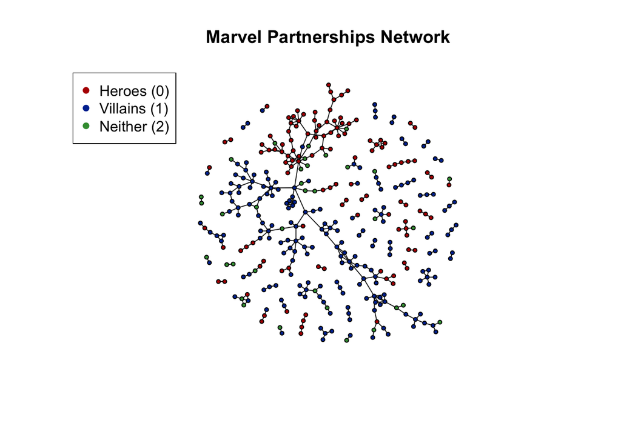

```r
V(marvel_network)$group <- marvel_nodes$group

plot(marvel_network,
     vertex.label = NA,
     vertex.size = 3,                        # node size
     edge.color = "gray15",                  # link line color
     vertex.color = group_colors[as.character(V(marvel_network)$group)],  # colors by group
     layout = cbind(V(marvel_network)$x, V(marvel_network)$y))  # for the coordinates

title("Marvel Partnerships Network", cex.main = 1.2)

# for the legend
legend("topleft",
       legend = c("Heroes (0)", "Villains (1)", "Neither (2)"),
       col = c("#B40000", "#0033A0", "#3C9A3F"),
       pch = 16,
       bty = "y")
```

[figure not shown]

```r
# plot with labels for the biggest nodes

# the degree of each node
degrees <- degree(marvel_network)

# determining a threshold for "biggest" nodes
threshold <- quantile(degrees, 0.98)

# identifying nodes with degree above our threshold
big_nodes <- V(marvel_network)[degrees > threshold]$character_name

# plotting the network with labels for the biggest nodes
plot(marvel_network,
     vertex.label = ifelse(degrees > threshold, V(marvel_network)$character_name, NA),
     vertex.size = degrees / max(degrees) * 10,
     edge.color = "gray15",
     vertex.color = group_colors[as.character(V(marvel_network)$group)],
     layout = cbind(V(marvel_network)$x, V(marvel_network)$y),
     vertex.label.family = "Marvel",
     vertex.label.cez = 0.5,
     vertex.label.color = "black")

par(family = "Marvel")
title("Marvel Partnerships Network", cex.main = 1.2)

# Add legend
legend("topleft",
       legend = c("Heroes (0)", "Villains (1)", "Neither (2)"),
       col = c("#B40000", "#0033A0", "#3C9A3F"),
       pch = 16,
       bty = "y",
       cex = 0.8,
       text.font = 2)
```

## 1.5 4. What is the number of nodes and links?

The number of nodes for the Marvel network is 350, meaning that the network consists of 350 different Marvel characters (Heroes, Villains, and Neither).

The number of links (the number of partnerships amongst all characters) is 346. This means that there are 346 different partnerships formed by the characters.

```r
# extracting number of nodes (characters) and links (partnerships)

num_nodes <- vcount(marvel_network)
num_links <- ecount(marvel_network)

# results
cat("Marvel Network Nodes:", num_nodes, "\nMarvel Network Links:", num_links, "\n")
```

```
Marvel Network Nodes: 350
Marvel Network Links: 346
```

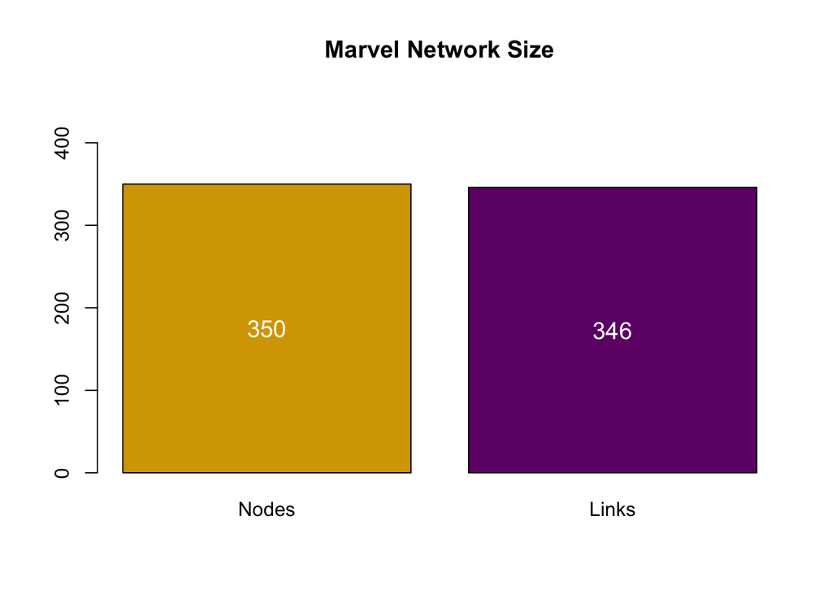

```r
# a simple plot

bp_nodes_links <- barplot(c(num_nodes, num_links),
              names.arg = c("Nodes", "Links"),
              main = "Marvel Network Size",
              col = c("#D6A400", "#6E0B75"),
              ylim = c(0, max(num_nodes, num_links) * 1.3))
text(bp_nodes_links, c(num_nodes, num_links) / 2,
     labels = c(num_nodes, num_links), col = "white", cex = 1.2)
```

##5. What is the average degree in the network? And the standard deviation of the degree?

We start with calculating the number of connections (links) for each node in the network. The degree function helps us count the number of incoming and outgoing links. This choice is due to the fact that the network is not a directed one (which means that connections go both ways, aka it takes two to tango).

Results show us that, on average, each Marvel character has about 2 (1.977143) partnerships.

As for the standard deviation, the number of partnerships per character typically differs from the average by 1.5 (1.54012). This implies that some characters have more or fewer partnerships by 1.5, which tells us that the number does not vary wildly.

```r
# calculating degrees, average links and standard deviations

degrees <- degree(marvel_network, mode = "all")
avg_degree <- mean(degrees)
std_dev_degree <- sd(degrees)

# results
cat("Average degree:", avg_degree, "\nStandard deviation:", std_dev_degree, "\n")
```

```
Average degree: 1.977143
Standard deviation: 1.54012
```

## 1.6 6. Plot the degree distribution in linear-linear scale and in log-log-scale. Does it have a typical connectivity? What is the degree of the most connected node?

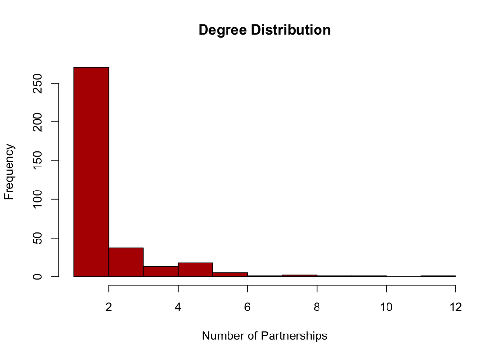

```r
# we previously calculated the degrees for all nodes:

# print(degrees)

# distribution of partnership numbers (linear-linear)

degrees <- degree(marvel_network, mode = "all")
hist(degrees, main = "Degree Distribution", xlab = "Number of Partnerships", col = "#B40000")
```

[figure not shown]

```r
# log-log

plot(table(degrees), log = "xy", main = "Degree Distribution (Log-Log)", xlab = "Degree", ylab = "Frequency", pch = 16, col = "#0033A0")
```

```r
max_degree <- max(degrees)
```

## 1.7 7. What is the clustering coefficient (transitivity) in the network?

Transitivity measures how often nodes’ neighbors are also connected. The transitivity value of 0.2194149 indicates that the network is more spread out than being tightly knit.

```r
clustering_coeff <- transitivity(marvel_network, type = "global")

#results
cat("Clustering coefficient:", clustering_coeff, "\n")
```

```
Clustering coefficient: 0.2194149
```

## 1.8 8. What is the assortativity (degree) in the network?

Assortativity measures if nodes with similar degrees connect (positive value) or if high-degree nodes connect to low-degree ones (negative value). As explained earlier, we use ‘directed = FALSE’ because our network is bidirectional, meaning that a link (partnership) requires two parties.

The result (assortativity degree of -0.011047) shows that in the Marvel network, characters with high numbers of partnerships slightly tend to connect with those with fewer partnerships, but the effect is very weak (because it is very close to 0), almost random.

```r
assortativity_degree <- assortativity_degree(marvel_network, directed = FALSE)

# result
cat("Assortativity (degree):", assortativity_degree, "\n")
```

```
Assortativity (degree): -0.011047
```

Visually:

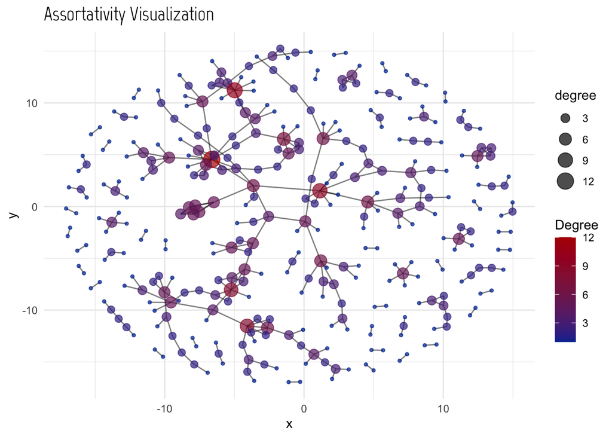

```r
# degrees
V(marvel_network)$degree <- degree(marvel_network)

ggraph(marvel_network, layout = "fr") +
  geom_edge_link(alpha = 0.5) +
  geom_node_point(aes(size = degree, color = degree), alpha = 0.7) +
  scale_color_gradient(low = "#0033A0", high = "#B40000") +
  theme_minimal() +
  labs(title = "Assortativity Visualization", color = "Degree") +
  theme(plot.title = element_text(family = "Marvel", size = 16))
```

## 1.9 9. Using the Louvain method, does the network have a community structure?

Yes. The network shows a community structure, as indicated by the Louvain community detection plot where nodes are grouped into distinct color clusters, suggesting characters form groups with more connections within clusters than between them.

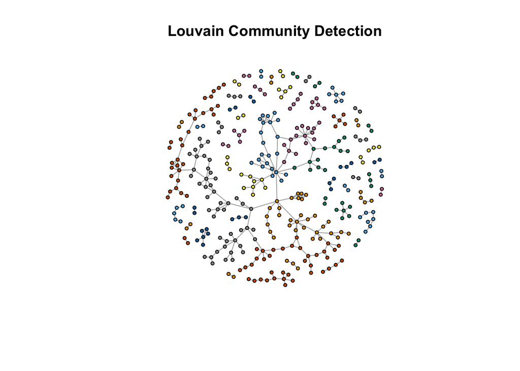

```r
set.seed(616)

# community detection using Louvain method
louvain_communities <- cluster_louvain(marvel_network)

# community membership for each node
V(marvel_network)$community <- membership(louvain_communities)

# network community plot
plot(marvel_network,
     vertex.label = NA,
     vertex.size = 3,
     vertex.color = V(marvel_network)$community,
     layout = layout_with_fr(marvel_network),
     main = "Louvain Community Detection",
     fontfamily = "Marvel")
```

## 1.10 10. If so, what is its modularity?**

Modularity score helps us decide to what extent the community structure demonstrates strong ties.

The modularity score of 0.92 (0.9116242), obtained using the Louvain community detection algorithm, indicates a very strong community structure in the Marvel network. This suggests that characters tend to form highly interconnected groups with few connections between groups — likely reflecting narrative-based teams or story arcs within the Marvel universe.

Characters tend to form tight clusters, most partnerships occurring within those clusters, and there are fewer cross-cluster partnerships than you would expect by chance.

```r
set.seed(616)
# modularity value of the communities
modularity_value <- modularity(louvain_communities)

cat("Modularity of the Louvain community structure:", modularity_value, "\n")
```

```
Modularity of the Louvain community structure: 0.9116242
```

## 1.11 11. Test that the clustering coefficient in the network cannot be statistically explained by a configuration model in which the nodes have the same degree distribution as the original.

After generating a degree-preserving rewired version of the Marvel network, we find that the clustering coefficient drops from 0.219 (the original Marvel network clustering coefficient) to 0.004 (the rewired graph clustering coefficient). This significant decrease suggests that the clustering structure observed in the real network is not explained by the degree distribution alone. Instead, it reflects meaningful group structures, such as narrative teams or recurring character associations in the Marvel universe.

The original Marvel network has much higher clustering than its degree-preserving random counterpart: characters that are connected to the same person tend to be connected to each other — suggesting intentional grouping or narrative structure (such as teams like Avengers or X-Men).

In the rewired version, where the number of connections for each character is preserved but partners are randomized, that natural tendency disappears.

```r
set.seed(616)

rewired_graph <- rewire(marvel_network, with = keeping_degseq(niter = ecount(marvel_network) * 10))

# the clustering coefficient for rewired version
rewired_transitivity <- transitivity(rewired_graph, type = "global")
cat("Clustering coefficient of rewired graph:", rewired_transitivity, "\n")
```

```
Clustering coefficient of rewired graph: 0.003989362
```

### 1.11.1 Comparing the two networks

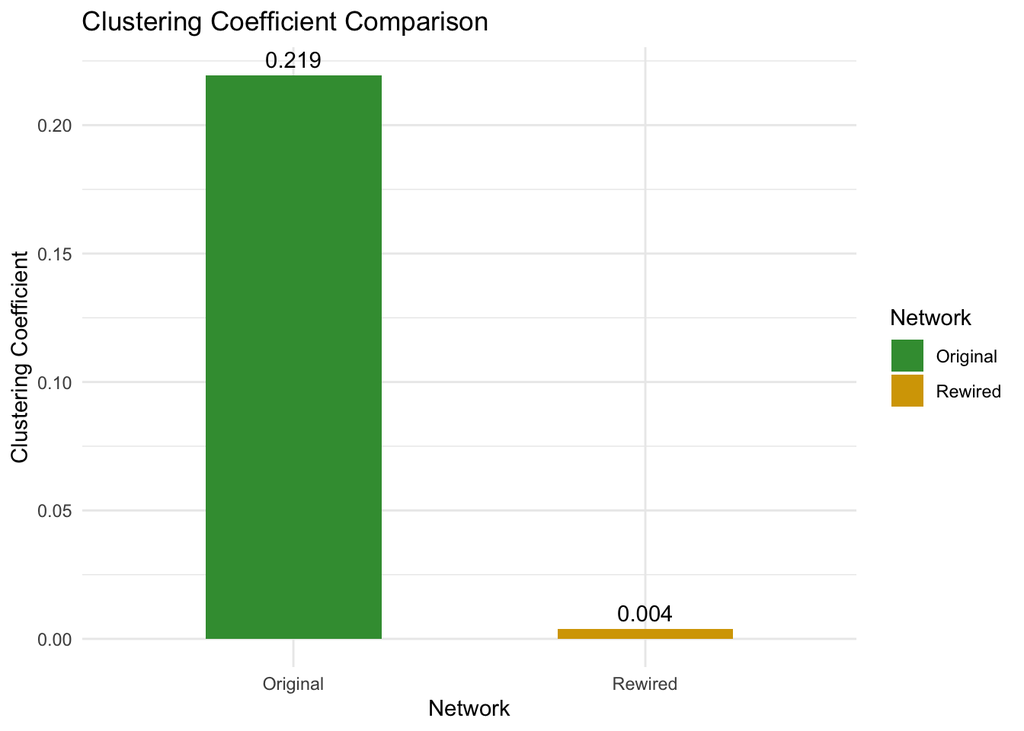

```r
data <- data.frame(Network = c("Original", "Rewired"),
                   Clustering = c(clustering_coeff, rewired_transitivity))
ggplot(data, aes(x = Network, y = Clustering, fill = Network)) +
  geom_col(width = 0.5) +
  geom_text(aes(label = round(Clustering, 3)), vjust = -0.5) +
  scale_fill_manual(values = c("Original" = "#3C9A3F", "Rewired" = "#D6A400")) +
  labs(title = "Clustering Coefficient Comparison", y = "Clustering Coefficient") +
  theme_minimal()
```

## 1.12 12. Visualize the neighborhood of the node with the largest centrality (closeness).

The neighbourhood of the node with the largest centrality belongs to Baron Zemo, a character which is not as popular and known as some others such as Spider-Man, Superman, and Captain America.

The reason why Baron Zemo appears as the node with the largest centrality is likely due to its strategic location. Although the character has few partnerships (low degree), his centrality in the network makes him a strategic person, allowing him to reach out to many characters in shortest paths. It is also very likely that he is close to the core of the network, which has short paths to other hubs in the network.

[figure not shown]

```r
# closeness centrality for each node
closeness_scores <- closeness(marvel_network, normalized = TRUE)

# the node with the highest closeness
max_closeness_node <- which.max(closeness_scores)

# the ego network (1-step neighborhood)
ego_net <- make_ego_graph(marvel_network, order = 1, nodes = max_closeness_node)[[1]]

# plot
plot(ego_net,
     vertex.label = V(ego_net)$character_name,
     vertex.size = 5,
     vertex.color = "#6E0B75",
     vertex.label.color = "black",
     edge.color = "gray30",
     main = paste("Neighborhood of:", V(marvel_network)$character_name[max_closeness_node]))
```

# 2 Conclusion